# MSIA Boot Camp - Final R exercise

You’ve learned quite a lot about R in a short time. Congratulations! This exercise is designed to give you some additional practice on the material we have discussed this week while the lectures are still fresh in your mind, and to integrate different tools and skills that you have learned.

## Instructions

#### Task 1: Import your data

Read the data files `nys_schools.csv` and `nys_acs.csv` into R. These data come from two different sources: one is data on *schools* in New York state from the [New York State Department of Education](http://data.nysed.gov/downloads.php), and the other is data on *counties* from the American Communities Sruvey from the US Census Bureau. Review the codebook file so that you know what each variable name means in each dataset.

```r
library(tidyverse)
library(lubridate)
nys_schools <- read_csv(here::here("data","nys_schools.csv"))
acs_counties <- read_csv(here::here("data","nys_acs.csv"))
```

#### Task 2: Explore your data

Getting to know your data is a critical part of data analysis. Take the time to explore the structure of the two dataframes you have imported. What types of variables are there? Is there any missing data? How can you tell? What else do you notice about the data?

```r
str(nys_schools)
```

```
## Classes 'tbl_df', 'tbl' and 'data.frame':    35663 obs. of  12 variables:
##  $ school_cd        : chr  "010100010014" "010100010014" "010100010014" "010100010014" ...
##  $ school_name      : chr  "MONTESSORI MAGNET SCHOOL" "MONTESSORI MAGNET SCHOOL" "MONTESSORI MAGNET SCHOOL" "MONTESSORI MAGNET SCHOOL" ...
##  $ district_name    : chr  "ALBANY CITY SCHOOL DISTRICT" "ALBANY CITY SCHOOL DISTRICT" "ALBANY CITY SCHOOL DISTRICT" "ALBANY CITY SCHOOL DISTRICT" ...
##  $ county_name      : chr  "ALBANY" "ALBANY" "ALBANY" "ALBANY" ...
##  $ region           : chr  "CAPITAL DISTRICT" "CAPITAL DISTRICT" "CAPITAL DISTRICT" "CAPITAL DISTRICT" ...
##  $ year             : int  2008 2009 2010 2011 2012 2013 2014 2015 2016 2017 ...
##  $ total_enroll     : int  316 312 300 326 294 321 335 347 366 359 ...
##  $ per_free_lunch   : num  0.33 0.32 0.26 0.22 0.31 0.25 0.35 0.22 0.29 0.26 ...
##  $ per_reduced_lunch: num  0.1 0.08 0.08 0.07 0.06 0.08 0.04 0 0.02 0.01 ...
##  $ per_lep          : num  0.01 0.02 0.03 0.03 0.03 0.03 0.06 0.06 0.05 0.07 ...
##  $ mean_ela_score   : num  658 673 670 667 670 ...
##  $ mean_math_score  : num  670 679 683 681 687 ...
##  - attr(*, "problems")=Classes 'tbl_df', 'tbl' and 'data.frame': 11 obs. of  5 variables:
##   ..$ row     : int  3101 13728 15274 20213 21395 21793 22463 25529 26067 26069 ...
##   ..$ col     : chr  "total_enroll" "total_enroll" "total_enroll" "total_enroll" ...
##   ..$ expected: chr  "no trailing characters" "no trailing characters" "no trailing characters" "no trailing characters" ...
##   ..$ actual  : chr  "e3" "e3" "e3" "e3" ...
##   ..$ file    : chr  "'/nfs/home/emg8426/bootcamp-2018/data/nys_schools.csv'" "'/nfs/home/emg8426/bootcamp-2018/data/nys_schools.csv'" "'/nfs/home/emg8426/bootcamp-2018/data/nys_schools.csv'" "'/nfs/home/emg8426/bootcamp-2018/data/nys_schools.csv'" ...
##  - attr(*, "spec")=List of 2
##   ..$ cols   :List of 12
##   .. ..$ school_cd        : list()
##   .. .. ..- attr(*, "class")= chr  "collector_character" "collector"
##   .. ..$ school_name      : list()
##   .. .. ..- attr(*, "class")= chr  "collector_character" "collector"
##   .. ..$ district_name    : list()
##   .. .. ..- attr(*, "class")= chr  "collector_character" "collector"
##   .. ..$ county_name      : list()
##   .. .. ..- attr(*, "class")= chr  "collector_character" "collector"
##   .. ..$ region           : list()
##   .. .. ..- attr(*, "class")= chr  "collector_character" "collector"
##   .. ..$ year             : list()
##   .. .. ..- attr(*, "class")= chr  "collector_integer" "collector"
##   .. ..$ total_enroll     : list()
##   .. .. ..- attr(*, "class")= chr  "collector_integer" "collector"
##   .. ..$ per_free_lunch   : list()
##   .. .. ..- attr(*, "class")= chr  "collector_double" "collector"
##   .. ..$ per_reduced_lunch: list()
##   .. .. ..- attr(*, "class")= chr  "collector_double" "collector"
##   .. ..$ per_lep          : list()
##   .. .. ..- attr(*, "class")= chr  "collector_double" "collector"
##   .. ..$ mean_ela_score   : list()
##   .. .. ..- attr(*, "class")= chr  "collector_double" "collector"
##   .. ..$ mean_math_score  : list()
##   .. .. ..- attr(*, "class")= chr  "collector_double" "collector"
##   ..$ default: list()
##   .. ..- attr(*, "class")= chr  "collector_guess" "collector"
##   ..- attr(*, "class")= chr "col_spec"
```

```r
head(nys_schools)
```

```
## # A tibble: 6 x 12
##   school_cd school_name district_name county_name region  year total_enroll
##   <chr>     <chr>       <chr>         <chr>       <chr>  <int>        <int>
## 1 01010001â¦ MONTESSORIâ¦ ALBANY CITY â¦ ALBANY      CAPITâ¦  2008          316
## 2 01010001â¦ MONTESSORIâ¦ ALBANY CITY â¦ ALBANY      CAPITâ¦  2009          312
## 3 01010001â¦ MONTESSORIâ¦ ALBANY CITY â¦ ALBANY      CAPITâ¦  2010          300
## 4 01010001â¦ MONTESSORIâ¦ ALBANY CITY â¦ ALBANY      CAPITâ¦  2011          326
## 5 01010001â¦ MONTESSORIâ¦ ALBANY CITY â¦ ALBANY      CAPITâ¦  2012          294
## 6 01010001â¦ MONTESSORIâ¦ ALBANY CITY â¦ ALBANY      CAPITâ¦  2013          321
## # ... with 5 more variables: per_free_lunch <dbl>,
## #   per_reduced_lunch <dbl>, per_lep <dbl>, mean_ela_score <dbl>,
## #   mean_math_score <dbl>
```

```r
dim(nys_schools)
```

```
## [1] 35663    12
```

```r
summary(nys_schools)
```

```
##   school_cd         school_name        district_name
##  Length:35663       Length:35663       Length:35663
##  Class :character   Class :character   Class :character
##  Mode  :character   Mode  :character   Mode  :character
##
##
##
##
##  county_name           region               year       total_enroll
##  Length:35663       Length:35663       Min.   :2008   Min.   : -99.0
##  Class :character   Class :character   1st Qu.:2010   1st Qu.: 339.0
##  Mode  :character   Mode  :character   Median :2013   Median : 469.0
##                                        Mean   :2013   Mean   : 523.4
##                                        3rd Qu.:2015   3rd Qu.: 648.0
##                                        Max.   :2017   Max.   :2347.0
##                                                       NA's   :11
##  per_free_lunch     per_reduced_lunch      per_lep
##  Min.   :-99.0000   Min.   :-99.00000   Min.   :-99.00000
##  1st Qu.:  0.1900   1st Qu.:  0.03000   1st Qu.:  0.00000
##  Median :  0.4200   Median :  0.06000   Median :  0.03000
##  Mean   :  0.4188   Mean   :  0.02852   Mean   :  0.04124
##  3rd Qu.:  0.7200   3rd Qu.:  0.10000   3rd Qu.:  0.11000
##  Max.   :257.0000   Max.   : 53.00000   Max.   :  1.00000
##
##  mean_ela_score  mean_math_score
##  Min.   :-99.0   Min.   :-99.0
##  1st Qu.:296.0   1st Qu.:298.0
##  Median :324.2   Median :330.8
##  Mean   :447.1   Mean   :456.0
##  3rd Qu.:666.3   3rd Qu.:683.5
##  Max.   :720.8   Max.   :738.7
##
```

```r
str(acs_counties)
```

```
## Classes 'tbl_df', 'tbl' and 'data.frame':    496 obs. of  5 variables:
##  $ county_name            : chr  "ALBANY" "ALBANY" "ALBANY" "ALBANY" ...
##  $ year                   : int  2009 2010 2011 2012 2013 2014 2015 2016 2009 2010 ...
##  $ county_per_poverty     : num  0.118 0.119 0.121 0.124 0.123 ...
##  $ median_household_income: int  55350 56090 57715 59359 59394 59940 59887 60904 40917 41305 ...
##  $ county_per_bach        : num  0.19 0.197 0.199 0.198 0.205 ...
##  - attr(*, "spec")=List of 2
##   ..$ cols   :List of 5
##   .. ..$ county_name            : list()
##   .. .. ..- attr(*, "class")= chr  "collector_character" "collector"
##   .. ..$ year                   : list()
##   .. .. ..- attr(*, "class")= chr  "collector_integer" "collector"
##   .. ..$ county_per_poverty     : list()
##   .. .. ..- attr(*, "class")= chr  "collector_double" "collector"
##   .. ..$ median_household_income: list()
##   .. .. ..- attr(*, "class")= chr  "collector_integer" "collector"
##   .. ..$ county_per_bach        : list()
##   .. .. ..- attr(*, "class")= chr  "collector_double" "collector"
##   ..$ default: list()
##   .. ..- attr(*, "class")= chr  "collector_guess" "collector"
##   ..- attr(*, "class")= chr "col_spec"
```

```r
head(acs_counties)
```

```
## # A tibble: 6 x 5
##   county_name  year county_per_poverty median_household_iâ¦ county_per_bach
##   <chr>       <int>              <dbl>               <int>           <dbl>
## 1 ALBANY       2009              0.118               55350           0.190
## 2 ALBANY       2010              0.119               56090           0.197
## 3 ALBANY       2011              0.121               57715           0.199
## 4 ALBANY       2012              0.124               59359           0.198
## 5 ALBANY       2013              0.123               59394           0.205
## 6 ALBANY       2014              0.129               59940           0.201
```

```r
dim(acs_counties)
```

```
## [1] 496   5
```

```r
summary(acs_counties)
```

```
##  county_name             year      county_per_poverty
##  Length:496         Min.   :2009   Min.   :0.04689
##  Class :character   1st Qu.:2011   1st Qu.:0.10903
##  Mode  :character   Median :2012   Median :0.12884
##                     Mean   :2012   Mean   :0.13085
##                     3rd Qu.:2014   3rd Qu.:0.14929
##                     Max.   :2016   Max.   :0.29935
##  median_household_income county_per_bach
##  Min.   : 33794          Min.   :0.07574
##  1st Qu.: 46347          1st Qu.:0.11018
##  Median : 50134          Median :0.13169
##  Mean   : 54116          Mean   :0.14410
##  3rd Qu.: 56448          3rd Qu.:0.17431
##  Max.   :102044          Max.   :0.31795
```

Variables deal with various demographic facts for both school districts and for counties in New York. Looking at the summary statistics for the data points, some have values of -99, which is a placeholder for a missing value, though there isn’t any missing data for the ACS survey, only for the NYS schools data.

#### Task 3: Recoding and variable manipulation

1. Deal with missing values, which are currently coded as `-99`.

```r
dim(nys_schools)
```

```
## [1] 35663    12
```

```r
nys_clean <- filter(nys_schools, !(total_enroll == -99.0 | per_free_lunch == -99.0000 | per_reduced_lunch == -99.00000 | per_lep == -99.00000 | mean_ela_score == -99.0 | mean_math_score == -99.0 | region == "-99"))
dim(nys_clean)
```

```
## [1] 33426    12
```

```r
#nys_schools[nys_schools == -99] <- NA would replace -99 with NA
```

2. Create a categorical variable that groups counties into “high”, “medium”, and “low” poverty groups. Decide how you want to split up the groups and briefly explain your decision.

```r
lower_quart <- mean(acs_counties$county_per_poverty) - sd(acs_counties$county_per_poverty)
upper_quart <- mean(acs_counties$county_per_poverty) + sd(acs_counties$county_per_poverty)

for (i in 1:nrow(acs_counties)) {
  if (acs_counties[i,"county_per_poverty"] > upper_quart) {
    acs_counties[i,"poverty"] = "high"
  } else if (acs_counties[i, "county_per_poverty"] >= lower_quart) {
    acs_counties[i,"poverty"] = "medium"
  } else {
    acs_counties[i,"poverty"] = "low"
  }
}
```

I grouped based on being one standard deviation about or below the mean value for the county_per_poverty. Those one SD above were high pvoerty, those one SD below were low.

3. The tests that the NYS Department of Education administers changes from time to time, so scale scores are not directly comparable year-to-year. Create a new variable that is the standardized z-score for math and English Language Arts (ELA) for each year (hint: group by year and use the `scale()` function)

```r
nys_clean_std <- nys_clean %>%
  group_by(year) %>%
  mutate(scaled_math = as.vector(scale(mean_math_score))) %>%
  mutate(scaled_ela = as.vector(scale(mean_ela_score)))
```

#### Task 4: Merge datasets

Create a county-level dataset that merges variables from the schools dataset and the ACS dataset. Remember that you have learned multiple approaches on how to do this, and that you will have to decide how to summarize data when moving from the school to the county level.

```r
nys_counties <- nys_clean_std %>%
  group_by(county_name,year) %>%
  summarize(county_enroll = sum(total_enroll), num_free_lunch = floor(sum(total_enroll*per_free_lunch)), num_reduced_lunch = floor(sum(total_enroll*per_reduced_lunch)), num_lep = floor(sum(total_enroll*per_lep)), mean_ela_score = mean(mean_ela_score), scaled_ela = mean(scaled_ela), mean_math_score = mean(mean_math_score), scaled_math = mean(scaled_math))

county_schools <- acs_counties %>%
  merge(nys_counties, by = c("county_name","year"))
```

#### Task 5: Create summary tables

Generate tables showing the following:

1. For each county: total enrollment, percent of students qualifying for free or reduced price lunch, and percent of population in poverty.

```r
county_schools_expanded <- county_schools %>%
  mutate(per_lunch = (num_free_lunch + num_reduced_lunch)/county_enroll)

select(county_schools_expanded, county_name, year, county_enroll, per_lunch, county_per_poverty)
```

```
##        county_name year county_enroll  per_lunch county_per_poverty
## 1           ALBANY 2009         25629 0.36805962         0.11835115
## 2           ALBANY 2010         26620 0.36577761         0.11940519
## 3           ALBANY 2011         26316 0.37099103         0.12072431
## 4           ALBANY 2012         25572 0.39203035         0.12375251
## 5           ALBANY 2013         25688 0.40225008         0.12297276
## 6           ALBANY 2014         25663 0.41179909         0.12861782
## 7           ALBANY 2015         26000 0.40384615         0.12797963
## 8           ALBANY 2016         25895 0.40726009         0.12260508
## 9         ALLEGANY 2009          5791 0.48333621         0.15215323
## 10        ALLEGANY 2010          5861 0.49240744         0.14919051
## 11        ALLEGANY 2011          5796 0.50948930         0.14839460
## 12        ALLEGANY 2012          5293 0.51728698         0.15289637
## 13        ALLEGANY 2013          5483 0.51340507         0.14745567
## 14        ALLEGANY 2014          5509 0.51697223         0.15245830
```

[output cut: 482 more lines]

2. For the counties with the top 5 and bottom 5 poverty rate: percent of population in poverty, percent of students qualifying for free or reduced price lunch, mean reading score, and mean math score.

```r
ranked_county_schools <- county_schools_expanded[order(county_schools_expanded$county_per_poverty),]
top5_county_schools <- ranked_county_schools[1:5,c("county_name","year","county_per_poverty","per_lunch","scaled_ela","scaled_math")]
top5_county_schools
```

```
##     county_name year county_per_poverty per_lunch scaled_ela scaled_math
## 233      NASSAU 2009         0.04688877 0.1686748  1.0262966   0.9430960
## 234      NASSAU 2010         0.04876069 0.1817329  0.9958831   0.8494989
## 320      PUTNAM 2016         0.05091140 0.1980907  0.5132481   0.4477262
## 235      NASSAU 2011         0.05154218 0.1973844  0.8530406   0.8420753
## 319      PUTNAM 2015         0.05238823 0.1694252  0.5406696   0.5338529
```

```r
bottom5_county_schools <- ranked_county_schools[492:496,c("county_name","year","county_per_poverty","per_lunch","scaled_ela","scaled_math")]
bottom5_county_schools
```

```
##    county_name year county_per_poverty per_lunch scaled_ela scaled_math
## 20       BRONX 2012          0.2855181 0.8601440 -0.8759987  -0.7118838
## 21       BRONX 2013          0.2901744 0.8556253 -0.7522849  -0.6588188
## 22       BRONX 2014          0.2968238 0.8601067 -0.6559438  -0.6444720
## 24       BRONX 2016          0.2976889 0.8428686 -0.4874464  -0.6496954
## 23       BRONX 2015          0.2993467 0.8550169 -0.5477351  -0.6765125
```

#### Task 6: Data visualization

Using `ggplot2`, visualize the following:

1. The relationship between access to free/reduced price lunch and test performance, at the *school* level.

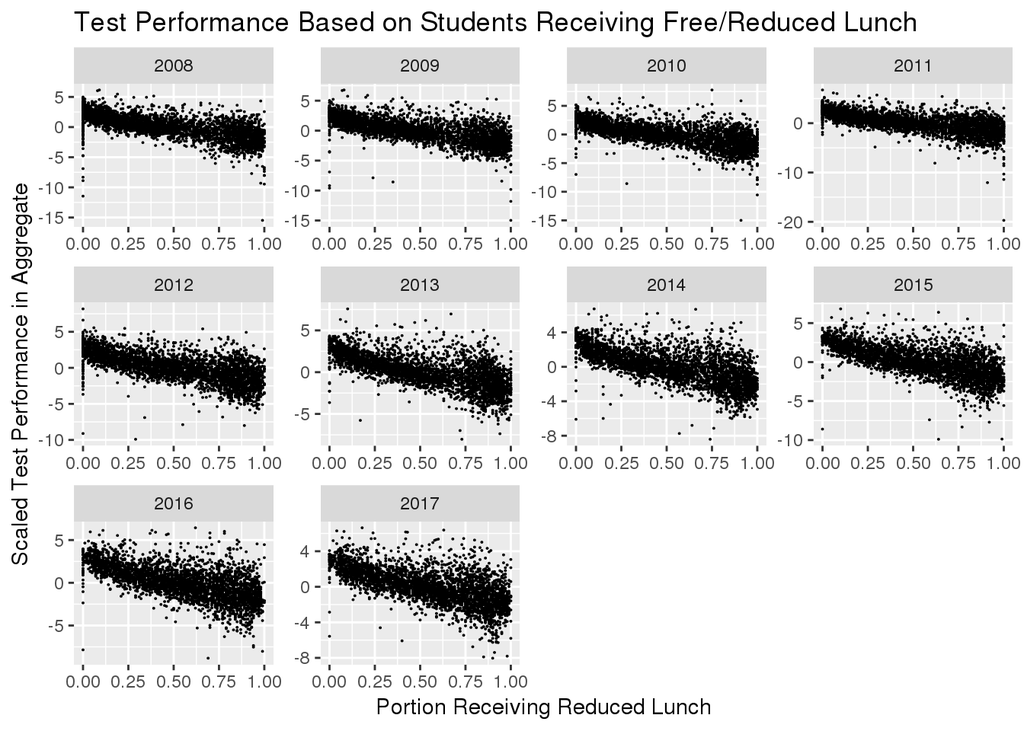

```r
nys_clean_std %>%
  filter(!((per_free_lunch + per_reduced_lunch)>1)) %>%
  ggplot() +
  geom_point(aes(x=(per_free_lunch + per_reduced_lunch), y=(scaled_math + scaled_ela)), size = .02)+
  facet_wrap(~year, scale="free") +
  labs(title = "Test Performance Based on Students Receiving Free/Reduced Lunch", x="Portion Receiving Reduced Lunch", y="Scaled Test Performance in Aggregate")
```

2. Average test performance across *counties* with high, low, and medium poverty.

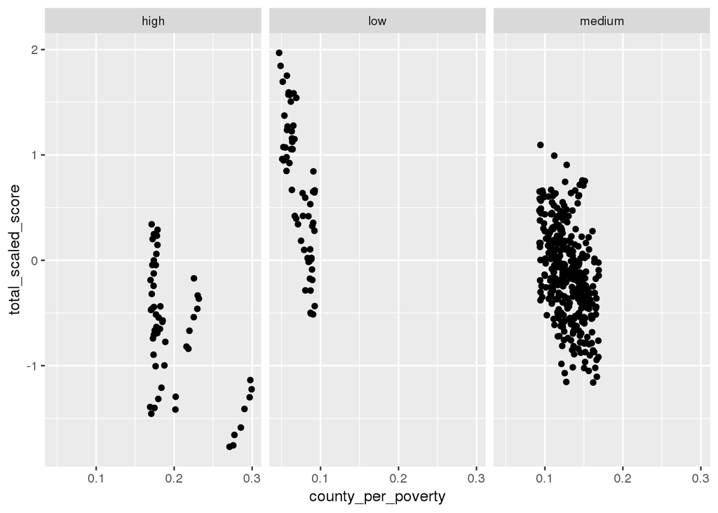

```r
county_schools_expanded %>%
  filter(!((per_lunch)>1)) %>%
  group_by(poverty, county_per_poverty) %>%
  summarize(total_scaled_score = mean(scaled_ela + scaled_math)) %>%
  ggplot() +
  geom_point(aes(x=county_per_poverty,y=total_scaled_score)) +
  facet_wrap(~poverty)
```

#### Task 7: Answering questions

Using the skills you have learned in the past three days, tackle the following question:

> What can the data tell us about the relationship between poverty and test performance in New York public schools? Has this relationship changed over time? Is this relationship at all moderated by access to free/reduced price lunch?

You may use summary tables, statistical models, and/or data visualization in pursuing an answer to this question. Feel free to build on the tables and plots you generated above in Tasks 5 and 6.

Given the short time period, any answer will of course prove incomplete. The goal of this task is to give you some room to play around with the skills you’ve just learned. Don’t hesitate to try something even if you don’t feel comfortable with it yet. Do as much as you can in the time allotted.

## Github submission

When you have completed the exercise, save your Markdown file in the `submissions` folder of your forked repo using this naming convention: `FinalRExercise_LastnameFirstname.Rmd`. Commit changes periodically, and push commits when you are done.

You can optionally create a pull request to submit this file (and other exercise files from the bootcamp sessions) to the base repo that lives in the MSiA organization. If you would like to do this, make sure that all new files you have created are in the `submissions` folder, and then create a pull request that asks to merge changes from your forked repo to the base repo.

## Reminders

- Remember to **load necessary packages**.
- Remember to **comment extensively** in your code. Since you will be working in an RMarkdown file, you can describe your workflow in the text section. But you should also comment within all of your code chunks.
- Attempt to knit your Markdown file into HTML format before committing it to Github. Troubleshoot any errors with the knit process by checking the lines referred to in the error messages.